# K-means clustering of junctions coordinates.

Quentin Goss `quentingoss0323@floridapoly.edu`

Florida Polytechnic University `COP5090.01`

30 October 2018

# Introduction

On this page we will perform k-means clustering on a SUMO map by using the junctions as points with `x` and `y` coordinates. For the following examples we will project `leopard` which has many points and when plotted, none of the points overlap any other points. Additionally, the project `leopard` was created using the SUMO tool NETEDIT and as such, the names of the junctions are short (i.e. `gneJ115`) whereas in a project important from OpenSteetMaps such as `Davenport`, the names of the junctions may be very long. A preview of the `leopard` junctions plotted by their `x` and `y` coordinates is shown in Figure 1.

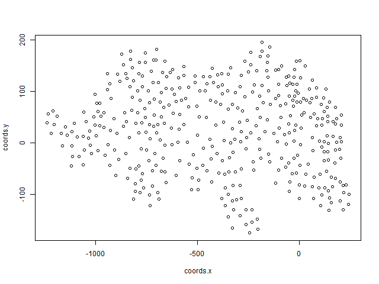

**Figure 1** – The junctions of project`leopard`plotted by the `x` and `y` coordinates of it’s junctions.

We will use the script `SUMO.project2plot.R` to retrieve the `true_center_coords` `x` and `y` coordinates and junction names from `junctions.json` in project `leopard`. We being by importing the script `SUMO.project2plot.R`.

```r
source(file='../scripts/SUMO.project2plot.R')
```

Before we can perform k-means clustering on our data we must structure the data to work with the built in R function `kmeans`. To start, we retrieve the `x`, `y` and `names` of our junctions by extracting the data from the `.json` file for the project `leopard` in the `jsons` directory.

```r
# Get a junctions.matrix from the json files for project `leopard`
junctions.matrix <- project.name2jm('leopard')
# Extract the data we want from junction.data at column 'True Coords' (default)
xynames <- jm2xynames(junctions.matrix)
# Summarize our object `xynames`
print(summary(xynames))
```

```
     Length Class  Mode
[1,] 412    -none- numeric
[2,] 412    -none- numeric
[3,] 412    -none- character
```

```r
# Unlist and give x, y, and names their own vectors.
coords.x <- unlist(xynames[1])
coords.y <- unlist(xynames[2])
coords.names <- unlist(xynames[3])
# Clean up
rm(junctions.matrix,xynames)
```

Next, we combine the coordinate data into a format readable by the `kmeans` function.

```r
coords.matrix <- cbind(coords.x,coords.y)
colnames(coords.matrix) <- c('x','y')
rownames(coords.matrix) <- coords.names
print(head(coords.matrix,n=10L))
```

```
              x       y
gneJ10    85.58  106.58
gneJ100 -261.90  -11.07
gneJ101 -289.27    2.26
gneJ103 -291.37  -81.94
gneJ104 -284.35 -107.19
gneJ106 -144.73  -36.33
gneJ107 -224.71  -52.47
gneJ109 -286.43  -50.56
gneJ11   129.67  104.45
gneJ110   -8.00  -23.63
```

Then we use the built in `kmeans` function to find some clusters.

```r
ncenters <- 6
coords.clusters <- kmeans(
  x = coords.matrix,
  centers = ncenters,
  iter.max = 50,
  nstart = 27,
  algorithm = 'Hartigan-Wong'
)
print(coords.clusters)
```

```
K-means clustering with 6 clusters of sizes 87, 56, 70, 49, 70, 80

Cluster means:
           x          y
1  -760.2152  41.606322
2  -519.9545  51.115179
3  -297.4576  -8.263143
4 -1042.4084  26.245102
5   135.1884 -20.882143
6   -66.2260  67.690250

Clustering vector:
 gneJ10 gneJ100 gneJ101 gneJ103 gneJ104 gneJ106 gneJ107 gneJ109  gneJ11 gneJ110 gneJ111 gneJ113 gneJ114 gneJ115 gneJ116
      5       3       3       3       3       6       3       3       5       6       6       6       5       5       5
gneJ117 gneJ118 gneJ119  gneJ12 gneJ120 gneJ121 gneJ122 gneJ123 gneJ124 gneJ125  gneJ14 gneJ148 gneJ149  gneJ15 gneJ150
      5       5       5       5       5       5       5       5       5       5       5       5       5       5       5
gneJ153 gneJ154 gneJ155 gneJ156 gneJ157 gneJ158  gneJ16 gneJ160 gneJ161 gneJ162 gneJ163 gneJ164 gneJ165 gneJ167 gneJ168
      5       5       5       5       5       5       5       3       2       2       1       2       2       2       2
gneJ169 gneJ170 gneJ171 gneJ172 gneJ174 gneJ175 gneJ176  gneJ18 gneJ180 gneJ182 gneJ183  gneJ19 gneJ191 gneJ192 gneJ193
      1       2       2       2       2       2       3       5       3       3       2       5       2       2       1
gneJ194 gneJ195 gneJ196 gneJ197 gneJ198 gneJ199   gneJ2  gneJ20 gneJ200 gneJ201 gneJ202 gneJ203 gneJ204 gneJ207 gneJ208
      1       1       2       2       1       1       5       5       1       1       1       1       1       1       1
gneJ209  gneJ21 gneJ210 gneJ211 gneJ214 gneJ215 gneJ216 gneJ217 gneJ218 gneJ219  gneJ22 gneJ220 gneJ221 gneJ222 gneJ223
      1       5       1       1       1       1       1       4       4       4       5       4       4       4       4
gneJ224 gneJ225 gneJ226 gneJ227  gneJ23 gneJ231 gneJ232 gneJ233 gneJ234 gneJ235 gneJ236 gneJ237 gneJ238 gneJ239  gneJ24
      4       4       4       4       5       4       4       4       4       4       4       4       4       1       5
gneJ240 gneJ241 gneJ242 gneJ245 gneJ246 gneJ247 gneJ249  gneJ25 gneJ250 gneJ251 gneJ252 gneJ253 gneJ254 gneJ255  gneJ26
      1       1       4       4       4       4       4       5       4       4       4       4       1       1       5
gneJ269  gneJ27 gneJ270 gneJ271 gneJ272 gneJ273  gneJ28 gneJ288 gneJ289 gneJ290 gneJ291 gneJ292   gneJ3  gneJ30 gneJ301
      1       5       1       1       1       3       5       3       3       3       3       3       5       5       3
gneJ302 gneJ303 gneJ304  gneJ31  gneJ32  gneJ33  gneJ34 gneJ343 gneJ344 gneJ345 gneJ346 gneJ347 gneJ348 gneJ349  gneJ35
      3       3       3       5       5       5       6       3       3       3       3       3       3       3       6
gneJ350 gneJ351 gneJ352 gneJ353 gneJ354 gneJ355 gneJ356 gneJ357 gneJ358 gneJ359 gneJ360 gneJ361 gneJ362 gneJ363 gneJ364
      3       3       3       3       3       3       3       3       3       3       3       3       3       3       3
gneJ365 gneJ366 gneJ367 gneJ368 gneJ369  gneJ37 gneJ370 gneJ371 gneJ372 gneJ373 gneJ374 gneJ376 gneJ377 gneJ378 gneJ379
      3       3       3       3       3       6       3       3       3       3       3       6       6       3       3
 gneJ38 gneJ380 gneJ381 gneJ382 gneJ383 gneJ384 gneJ385 gneJ386 gneJ387 gneJ388 gneJ389  gneJ39 gneJ390 gneJ391 gneJ392
      6       6       6       6       6       3       6       3       6       3       6       6       6       6       6
gneJ393 gneJ394 gneJ395 gneJ396 gneJ397 gneJ398 gneJ399  gneJ40 gneJ400 gneJ401 gneJ402 gneJ403 gneJ404 gneJ405 gneJ406
      6       5       5       5       6       6       6       6       6       6       6       6       6       6       6
```

[output cut: 22 more lines]

```
gneJ577 gneJ578  gneJ58 gneJ580 gneJ581   gneJ6  gneJ62  gneJ66  gneJ67  gneJ68  gneJ69  gneJ71  gneJ72  gneJ73  gneJ74
      4       4       6       6       5       5       6       5       5       5       5       6       6       6       6
 gneJ75  gneJ76  gneJ77  gneJ78  gneJ79   gneJ8  gneJ80  gneJ81  gneJ82  gneJ84  gneJ85  gneJ86  gneJ87  gneJ88  gneJ89
      6       6       6       6       6       5       6       6       3       6       3       3       6       6       3
  gneJ9  gneJ90  gneJ91  gneJ92  gneJ93  gneJ97  gneJ99
      5       3       3       2       2       3       3

Within cluster sum of squares by cluster:
[1] 1034288.4  578099.4  897166.8  543155.6  539419.8  787579.8
 (between_SS / total_SS =  93.4 %)

Available components:

[1] "cluster"      "centers"      "totss"        "withinss"     "tot.withinss" "betweenss"    "size"         "iter"
[9] "ifault"
```

Finally, we view the plot of our `kmeans` clustered junction data.

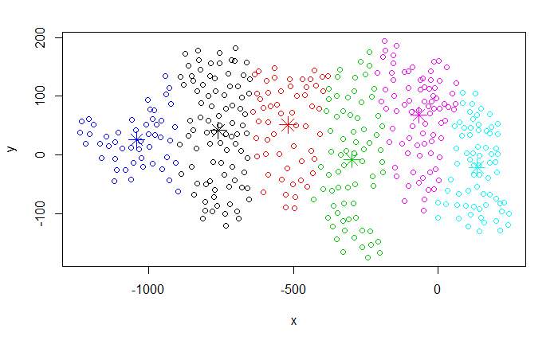

```r
plot(x = coords.matrix, col = coords.clusters$cluster)
points(coords.clusters$centers, col = 1:ncenters , pch = 8, cex = 2)
```